# Social Media Behaviour Analytics & Well-Being

2026-06-15

## Section 1: Introduction

**Abstract:**

Social media has become a major part of student life, influencing how students communicate, access information, relax, and participate in campus communities. At the same time, excessive social media use has raised concerns about its potential relationship with mental health, sleep quality, and student engagement.

This study investigates the relationship between social media usage and student well-being among university students. A structured Google Forms questionnaire was distributed through the Piazza platform and in-person interactions, collecting responses related to social media usage, perceived mental health impact, sleep patterns, campus engagement, and exposure to positive social media content. The final dataset contained 75 student responses, including 40 international students and 35 domestic students.

**Introduction:**

Social media platforms such as Instagram, Snapchat, X, TikTok, and similar applications are now deeply embedded in daily life. For university students, social media can serve as a source of entertainment, communication, academic coordination, and social connection. However, frequent or excessive use may also be associated with negative outcomes, including disrupted sleep, stress, reduced focus, and exposure to harmful or emotionally distressing content.

Previous research has suggested that social media usage may be linked to mental health concerns, including anxiety, depression, cognitive strain, and sleep-related problems. These concerns are particularly relevant for university students, who often manage academic demands, social pressures, and transitional life experiences. Understanding how social media usage relates to student well-being can therefore provide useful insight for students, educators, and campus support systems.

This study examines how social media usage is associated with several indicators of student well-being, including perceived mental health impact, sleep disruption, and campus engagement. The study also considers whether exposure to positive social media content appears to influence perceived mental health outcomes.

The analysis is guided by the following research questions:

1. **What are the effects of social media on students’ sleep pattern and overall mental and physical health?**
   - Null Hypothesis: Social media has no influence on students’ sleep pattern and overall mental/physical health
   - Alternative Hypothesis: Social media has influence on students’ sleep pattern and overall mental/physical health
2. **How does social media influence university students’ participation in campus activities and (mental health) events?**
   - Null Hypothesis: Social Media does not influence the participation of students in campus activities and (mental health) events
   - Alternative Hypothesis: Social Media does show influence on university students’ participation in campus activities and (mental health) events
3. **How does exposure to positive social media content influence students’ perceived mental health impact?**
   - Null Hypothesis: Exposure to positive social media content does not influence students’ perceived mental health impact.
   - Alternative Hypothesis: Exposure to positive social media content influences students’ perceived mental health impact.

We have structured this document with different sections focusing on different aspects of the research article, where Section 2 discusses the methods of data collection, followed by Section 3 with the major portion of our sample quantitative analysis. The Discussions/Results will be briefed in the fourth section. Sections 5 and 6 cover the Limitations of our Study and the Conclusion, respectively. The Appendix consisting of the R-codes will be presented in the Section 7.

## Section 2: Methods of Data Collection

**Methods of Data Collection:**

From late September 2024 through October 2024, a questionnaire consisting of 12 questions was distributed to university students through the Piazza platform and in-person interactions. The survey collected quantitative and qualitative information regarding social media usage, perceived impacts on sleep quality, perceived mental health effects, and participation in campus activities. The study used stratified sampling by dividing respondents into domestic and international student groups. A target sample of 40 students from each stratum was selected to support comparison across the two groups. In total, all 40 international students and 35 domestic students responded, producing a final sample size of n = 75.

### Data Dictionary

The following variables were collected through the survey questionnaire and subsequently used throughout the statistical analyses presented in this report.

| Variable | Description | Scale / Coding |
| --- | --- | --- |
| Student.Status | Student residency status used for stratification | D = Domestic Student, I = International Student |
| Social.Media.Usage | Self-reported daily social media usage level | 1 = Very Low Usage, 5 = Very High Usage |
| Impact.on.Sleep.Pattern | Perceived impact of social media on sleep quality and sleep schedule | 1 = No Impact, 5 = Strong Impact |
| Impact.on.Mental.Health | Perceived impact of social media on mental well-being | 1 = No Impact, 5 = Strong Impact |
| Average.Sleep.Hours | Average number of hours slept per night | Numeric (Hours) |
| Campus.Engagement.Influence | Degree to which social media influences participation in campus activities and events | 1 = No Influence, 5 = Strong Influence |
| Positive.Content.Encounter.Frequency | Frequency of encountering positive or uplifting content on social media platforms | 1 = Very Rarely, 5 = Very Frequently |

#### Notes on Variable Coding

All perception-based variables were measured using a five-point Likert scale, where larger values indicate a greater perceived influence or frequency. Student status was used as the stratification variable throughout the analysis, allowing comparisons between domestic and international student populations.

The variables selected for analysis were chosen to evaluate the relationship between social media usage and several indicators of student well-being, including sleep quality, mental health, and campus engagement.

## Section 3: Data Analysis

**Data Analysis:**

A key component of the study design was determining an appropriate sample size for estimating population-level patterns. Assuming a population size of N = 200, the required sample size $n$ was estimated using the following formula:

$n = \frac{Npq}{(N - 1)D + pq}$

where:

- $N = 200$ (population size),
- $p = 0.5$ (estimated proportion, assuming maximum variability),
- $q = 1 - p = 0.5$,
- $b = 0.085$ (bound or margin of error, 8.5%),
- $D = \frac{b^2}{4}$.

### Sample Size Calculations:

1. Calculate $D$:

   $D = \frac{b^2}{4} = \frac{(0.085)^2}{4} = 0.00180625$
2. Substitute values into the sample size formula:

After collecting survey responses, we calculated descriptive statistics for both strata. The following tables summarize social media usage, perceived impacts on sleep patterns, perceived impacts on mental health, and average sleep hours for international and domestic students.

International:

[output not shown]

Domestic:

[output not shown]

This summary data from both strata provides information on the mean, median, min/max and quartiles for social media usage, impact on sleep pattern and mental health, and average sleep hour data. These summaries are critical to ensure that we can meet the conditions of the statistical tests that will be conducted in the forthcoming analysis. Understanding the variability and distribution of the data could support our comparison of mean and ANOVA test results which will be the basis of our investigation.

**Simple Linear Regressions (Strata-wise): [Social Media Usage VS Impact on Sleep Pattern] & [Social Media Usage VS Impact on Mental Health]**

Figures 1–4 present the simple linear regression relationships between social media usage and two student well-being indicators: perceived mental health impact and perceived sleep disruption. Separate analyses are shown for international and domestic student populations to facilitate comparison between the two strata.

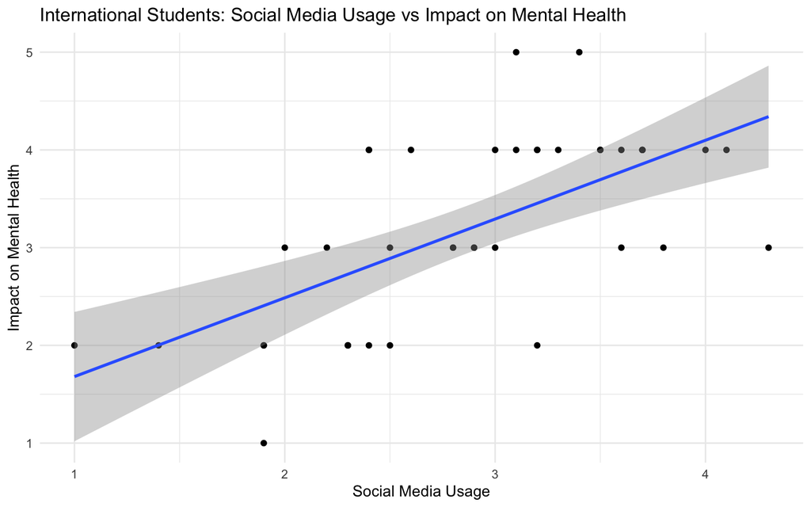

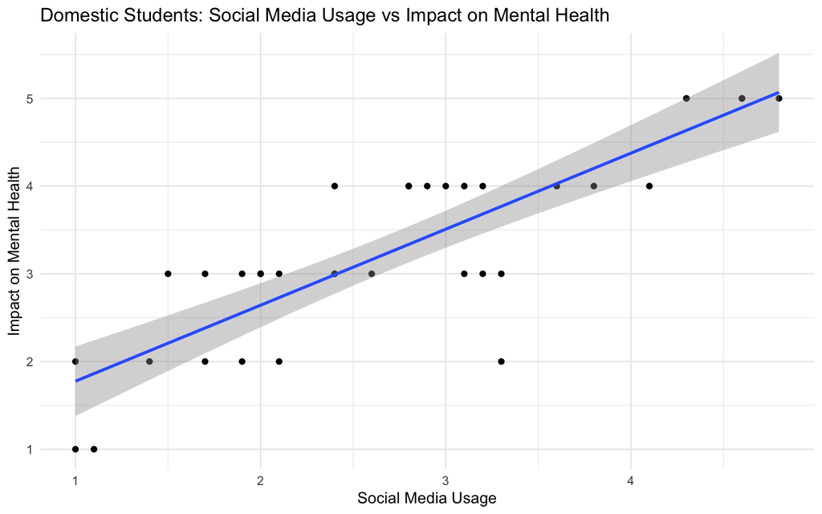

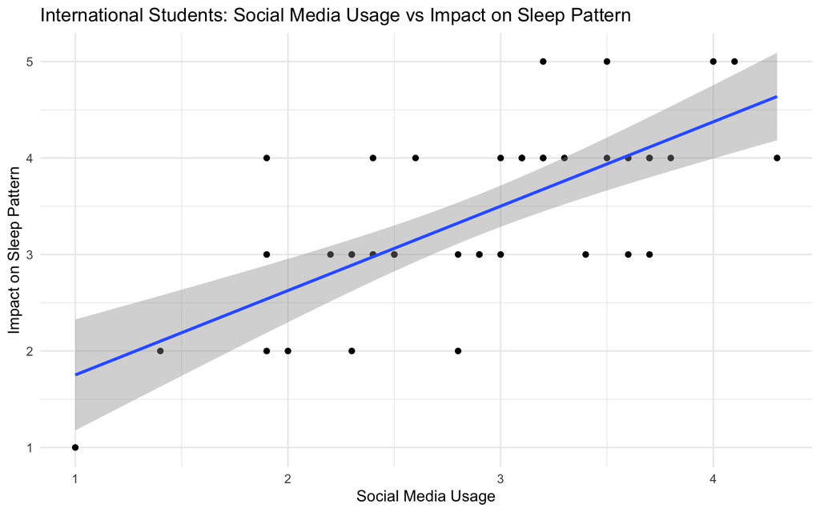

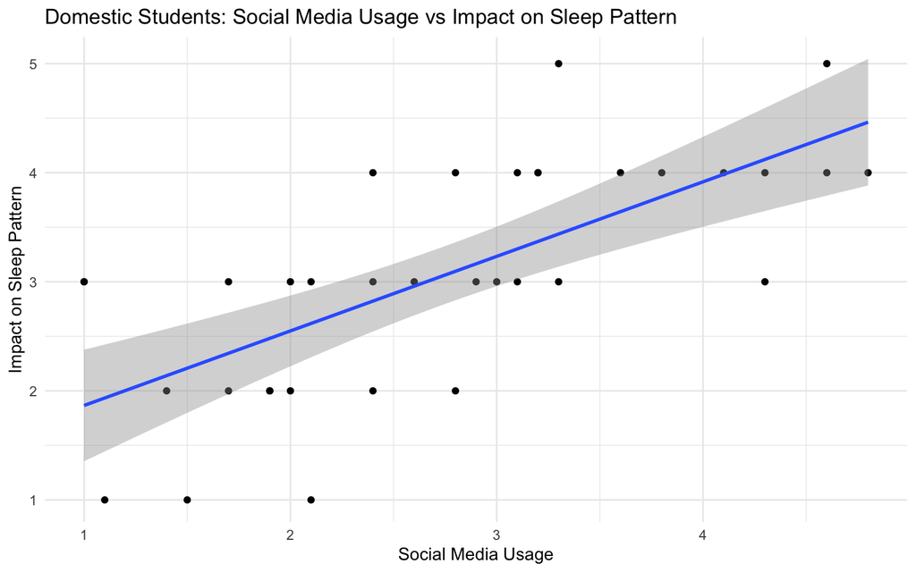

**Figure 1. International Students: Social Media Usage vs Impact on Mental Health.** Scatterplot with fitted least-squares regression line illustrating the positive relationship between self-reported social media usage and perceived mental health impact among international students.

**Figure 2. Domestic Students: Social Media Usage vs Impact on Mental Health.** Scatterplot with fitted least-squares regression line illustrating the positive relationship between self-reported social media usage and perceived mental health impact among domestic students.

**Figure 3. International Students: Social Media Usage vs Impact on Sleep Pattern.** Scatterplot with fitted least-squares regression line illustrating the association between social media usage and perceived sleep disruption among international students.

**Figure 4. Domestic Students: Social Media Usage vs Impact on Sleep Pattern.** Scatterplot with fitted least-squares regression line illustrating the association between social media usage and perceived sleep disruption among domestic students.

[output not shown]

In terms of the p-values, which are much below the $\alpha$ = 0.05 significance level, we can confirm that the influence of social media on sleep patterns and mental health is non-zero, and there is a positive relation between social media, where increased social media usage results in greater (negative) impact on both sleep patterns and mental health, thus, impacting the student well-being parameters (sleep and mental health). Hence, in terms of just the simple linear regression we can come to a conclusion on our first research question, and reject the null hypothesis, as provided above.

**Comparison of Means-Test (Strata-wise):**

Summary of the Comparison of Means - Test:

[output not shown]

[output not shown]

**Multiple Linear Regression (Strata-wise):**

The form of the multiple linear regression is ‘impact on mental health = intercept + $b_1 *$ social media + $b_2 *$average hours of sleep + $b_3 *$ social media $*$ positive content’. The summary table from this analysis on both the stratas (international and domestic) yields:

International:

[output not shown]

Domestic Students:

[output not shown]

From a general perspective of analysis, altogether positive content or average sleep time is not a significant factor that could cause fluctuations within the impact on mental health. We get a very specific case where positive content could influence our well-being parameter, however all other tests show that this explanatory variable shows no constant trend with student well-being. This is a matter of further analysis for the third research question we are addressing.

International Students - Campus Engagement Influence

[output not shown]

Domestic Students - Campus Engagement Influence

[output not shown]

[output not shown]

[output not shown]

## Section 4: Discussion of Results

**Discussion of Results:**

The simple linear regression analysis revealed a positive relationship between social media usage and both perceived sleep disruption and perceived mental health impact for international and domestic students. The estimated coefficients indicate that higher levels of social media usage are associated with greater reported impacts on sleep patterns and mental health. Furthermore, the statistically significant p-values (all below the significance level of α = 0.05) provide strong evidence against the null hypothesis, suggesting that social media usage is a meaningful predictor of these well-being outcomes. Consequently, we reject the null hypothesis associated with the first research question. In contrast, additional analyses examining the relationship between social media usage and campus engagement did not produce statistically significant results. This suggests that, within the scope of this study, social media usage does not appear to be a strong determinant of students’ participation in campus activities or events.

## Section 5: Limitations of the Study

**Limitations of our Study**

One limitation of this study is the absence of open-ended qualitative responses. While the survey successfully captured quantitative measures of social media usage and perceived well-being outcomes, qualitative responses could have provided additional context regarding how students interpret the effects of social media on their daily lives. Such information may have offered deeper insight into the mechanisms through which social media influences mental health, sleep patterns, and campus engagement.

A second limitation concerns the measurement of campus engagement and sleep-related outcomes. The study relied on a limited number of survey variables to represent these complex behaviours, and social media usage is unlikely to be the sole factor influencing either outcome. Additional variables such as academic workload, employment commitments, extracurricular involvement, and personal circumstances may also contribute meaningfully to student well-being. Future studies incorporating a broader range of explanatory variables may provide a more comprehensive understanding of these relationships.

## Section 6: Conclusion

**Conclusion**

This study investigated the impacts of social media on the university students’ mental well-being, characterized by sleep patterns, engagement in campus events and overall influence on mental health. Our findings after conducting all of the critical tests showcases that social media usage has a statistically significant impact on the mental well-being of students, both in terms of their sleep quality and their perception of its impact on their mental health. However, social media’s effect on campus engagement was not statistically significant, indicating that students’ participation in campus events appears largely unaffected by their social media habits. Furthermore, our analysis has revealed that positive content exposure did not demonstrate a statistically significant relationship with perceived mental health impact within this sample. This suggests that additional explanatory variables not included in the present study may also contribute meaningfully to student well-being outcomes. Therefore, we fail to reject the null hypothesis for research questions 2 and 3, respectively, while we can confidently reject the null hypothesis for the first research question.

Future research should expand the range of explanatory variables considered when examining student well-being and social media usage. Incorporating larger samples, qualitative responses, and longitudinal data collection may provide a more comprehensive understanding of how social media influences mental health, sleep patterns, and campus engagement over time. Such improvements would strengthen the ability to identify underlying mechanisms and produce findings that are more broadly generalizable.

In conclusion, while this study provides valuable insight into the relationship between social media usage and student well-being, it also highlights the importance of continued research to better understand the complex factors that contribute to students’ mental health, sleep patterns, and campus engagement.

## Section 7: Appendix

### Reference

1. Bhandarkar, P. (2021). *Social Media and Mental Health: Implications for Young Adults.*

### R Code

```r
# R Code for Social Media Behaviour Analytics & Well-Being

# International Students
str(international_data)
```

```
## 'data.frame':    40 obs. of  7 variables:
##  $ Student.Status                      : chr  "I" "I" "I" "I" ...
##  $ Social.Media.Usage                  : num  3.5 2.8 2.3 2.9 3.1 2.3 2.5 1.4 1 3.2 ...
##  $ Impact.on.Sleep.Pattern             : int  4 3 3 3 4 3 3 2 1 5 ...
##  $ Impact.on.Mental.Health             : int  4 3 2 3 4 2 2 2 2 4 ...
##  $ Average.Sleep.Hours                 : num  8.5 6.5 5.5 6.5 6.5 9 6.5 7 7 7 ...
##  $ Campus.Engagement.Influence         : int  2 3 5 4 5 4 4 2 4 4 ...
##  $ Positive.Content.Encounter.Frequency: int  3 5 4 3 1 5 2 2 1 4 ...
```

```r
summary(international_data)
```

```
##  Student.Status     Social.Media.Usage Impact.on.Sleep.Pattern
##  Length:40          Min.   :1.000      Min.   :1.0
##  Class :character   1st Qu.:2.375      1st Qu.:3.0
##  Mode  :character   Median :2.950      Median :3.0
##                     Mean   :2.885      Mean   :3.4
##                     3rd Qu.:3.500      3rd Qu.:4.0
##                     Max.   :4.300      Max.   :5.0
##  Impact.on.Mental.Health Average.Sleep.Hours Campus.Engagement.Influence
##  Min.   :1.0             Min.   :5.000       Min.   :1.00
##  1st Qu.:2.0             1st Qu.:6.500       1st Qu.:2.00
##  Median :3.0             Median :7.000       Median :3.00
##  Mean   :3.2             Mean   :6.825       Mean   :3.05
##  3rd Qu.:4.0             3rd Qu.:7.500       3rd Qu.:4.00
##  Max.   :5.0             Max.   :9.000       Max.   :5.00
##  Positive.Content.Encounter.Frequency
##  Min.   :1.00
##  1st Qu.:1.75
##  Median :3.00
##  Mean   :2.85
##  3rd Qu.:4.00
##  Max.   :5.00
```

```r
# Domestic Students
str(domestic_data)
```

```
## 'data.frame':    35 obs. of  7 variables:
##  $ Student.Status                      : chr  "D" "D" "D" "D" ...
##  $ Social.Media.Usage                  : num  3.3 1.9 1 2.9 2.1 4.8 1.7 2.6 3.2 4.3 ...
##  $ Impact.on.Sleep.Pattern             : int  5 2 3 3 3 4 3 3 4 3 ...
##  $ Impact.on.Mental.Health             : int  3 2 1 4 3 5 3 3 3 5 ...
##  $ Average.Sleep.Hours                 : num  5 7 8.5 5 8 6.5 6 7 9 8 ...
##  $ Campus.Engagement.Influence         : int  2 3 2 5 5 3 1 1 4 4 ...
##  $ Positive.Content.Encounter.Frequency: int  1 4 5 1 4 4 2 5 2 2 ...
```

```r
summary(domestic_data)
```

```
##  Student.Status     Social.Media.Usage Impact.on.Sleep.Pattern
##  Length:35          Min.   :1.000      Min.   :1.000
##  Class :character   1st Qu.:1.950      1st Qu.:2.000
##  Mode  :character   Median :2.800      Median :3.000
##                     Mean   :2.743      Mean   :3.057
##                     3rd Qu.:3.300      3rd Qu.:4.000
##                     Max.   :4.800      Max.   :5.000
##  Impact.on.Mental.Health Average.Sleep.Hours Campus.Engagement.Influence
##  Min.   :1.000           Min.   :5           Min.   :1.000
##  1st Qu.:3.000           1st Qu.:6           1st Qu.:2.000
##  Median :3.000           Median :7           Median :3.000
##  Mean   :3.286           Mean   :7           Mean   :2.914
##  3rd Qu.:4.000           3rd Qu.:8           3rd Qu.:4.000
##  Max.   :5.000           Max.   :9           Max.   :5.000
##  Positive.Content.Encounter.Frequency
##  Min.   :1.000
##  1st Qu.:2.000
##  Median :3.000
##  Mean   :3.029
##  3rd Qu.:4.000
##  Max.   :5.000
```

```r
# --- Simple Linear Regression ---
# Examine the relationship between Social Media Usage and Impact on Mental Health for both strata

# International Students - Simple Linear Regression
simple_lm_international <- lm(international_data$Impact.on.Mental.Health ~ international_data$Social.Media.Usage)
summary(simple_lm_international)
```

```
##
## Call:
## lm(formula = international_data$Impact.on.Mental.Health ~ international_data$Social.Media.Usage)
##
## Residuals:
##      Min       1Q   Median       3Q      Max
## -1.45392 -0.48662  0.05369  0.47745  1.62669
##
## Coefficients:
##                                       Estimate Std. Error t value Pr(>|t|)
## (Intercept)                             0.8745     0.4804    1.82   0.0766 .
## international_data$Social.Media.Usage   0.8061     0.1612    5.00 1.33e-05 ***
## ---
## Signif. codes:  0 '***' 0.001 '**' 0.01 '*' 0.05 '.' 0.1 ' ' 1
##
## Residual standard error: 0.7601 on 38 degrees of freedom
## Multiple R-squared:  0.3968, Adjusted R-squared:  0.381
## F-statistic:    25 on 1 and 38 DF,  p-value: 1.327e-05
```

```r
# Domestic Students - Simple Linear Regression
simple_lm_domestic <- lm(domestic_data$Impact.on.Mental.Health ~ domestic_data$Social.Media.Usage)
summary(simple_lm_domestic)
```

```
##
## Call:
## lm(formula = domestic_data$Impact.on.Mental.Health ~ domestic_data$Social.Media.Usage)
##
## Residuals:
##     Min      1Q  Median      3Q     Max
## -1.7685 -0.4219  0.1049  0.3848  1.0114
##
## Coefficients:
##                                  Estimate Std. Error t value Pr(>|t|)
## (Intercept)                       0.90877    0.28103   3.234  0.00277 **
## domestic_data$Social.Media.Usage  0.86659    0.09561   9.064 1.79e-10 ***
## ---
## Signif. codes:  0 '***' 0.001 '**' 0.01 '*' 0.05 '.' 0.1 ' ' 1
##
## Residual standard error: 0.5977 on 33 degrees of freedom
## Multiple R-squared:  0.7134, Adjusted R-squared:  0.7048
## F-statistic: 82.16 on 1 and 33 DF,  p-value: 1.787e-10
```

```r
# --- Comparison of Means Test ---
# Compare mean Campus Engagement for students having greater than 4 hours on social media versus those with less (strata-wise)

# Filter the data for students using social media more than 4 hours and 4 hours or less
more_than_4 <- subset(data, data$Social.Media.Usage > 4)
four_or_less <- subset(data, data$Social.Media.Usage <= 4)

# Separating by strata within each usage group
international_more_than_4 <- subset(more_than_4, more_than_4$Student.Status == "I")
international_four_or_less <- subset(four_or_less, four_or_less$Student.Status == "I")

domestic_more_than_4 <- subset(more_than_4, more_than_4$Student.Status == "D")
domestic_four_or_less <- subset(four_or_less, four_or_less$Student.Status == "D")

# Perform t-test for Campus Engagement Influence (International Students)
t_test_intl <- t.test(international_more_than_4$Campus.Engagement.Influence, international_four_or_less$Campus.Engagement.Influence)
print("International Students T-test Results")
```

```
## [1] "International Students T-test Results"
```

```r
print(t_test_intl)
```

```
##
##  Welch Two Sample t-test
##
## data:  international_more_than_4$Campus.Engagement.Influence and international_four_or_less$Campus.Engagement.Influence
## t = -0.026191, df = 1.0193, p-value = 0.9833
## alternative hypothesis: true difference in means is not equal to 0
## 95 percent confidence interval:
##  -24.47435  24.36909
## sample estimates:
## mean of x mean of y
##  3.000000  3.052632
```

```r
# Perform t-test for Campus Engagement Influence (Domestic Students)
t_test_dom <- t.test(domestic_more_than_4$Campus.Engagement.Influence, domestic_four_or_less$Campus.Engagement.Influence)
print("Domestic Students T-test Results")
```

```
## [1] "Domestic Students T-test Results"
```

```r
print(t_test_dom)
```

```
##
##  Welch Two Sample t-test
##
## data:  domestic_more_than_4$Campus.Engagement.Influence and domestic_four_or_less$Campus.Engagement.Influence
## t = -1.6366, df = 8.7297, p-value = 0.1372
## alternative hypothesis: true difference in means is not equal to 0
## 95 percent confidence interval:
##  -2.1554019  0.3508042
## sample estimates:
## mean of x mean of y
##  2.166667  3.068966
```

```r
# --- Multiple Linear Regression ---
# Examining the influence of Social Media Usage, Positive Content, and Average Sleep Hours on Impact on Mental Health Using Interactions

# International Students - Multiple Linear Regression
multiple_lm_international <- lm(international_data$Impact.on.Mental.Health ~ international_data$Social.Media.Usage +
                         international_data$Average.Sleep.Hours +
                         international_data$Social.Media.Usage * international_data$Positive.Content.Encounter.Frequency)
summary(multiple_lm_international)
```

```
##
## Call:
## lm(formula = international_data$Impact.on.Mental.Health ~ international_data$Social.Media.Usage +
##     international_data$Average.Sleep.Hours + international_data$Social.Media.Usage *
##     international_data$Positive.Content.Encounter.Frequency)
##
## Residuals:
##      Min       1Q   Median       3Q      Max
## -1.37218 -0.54090 -0.03677  0.47440  1.44711
##
## Coefficients:
##                                                                                               Estimate
## (Intercept)                                                                                    1.60300
## international_data$Social.Media.Usage                                                          0.31115
## international_data$Average.Sleep.Hours                                                         0.07732
## international_data$Positive.Content.Encounter.Frequency                                       -0.51923
## international_data$Social.Media.Usage:international_data$Positive.Content.Encounter.Frequency  0.20363
##                                                                                               Std. Error
## (Intercept)                                                                                      1.27204
## international_data$Social.Media.Usage                                                            0.33528
## international_data$Average.Sleep.Hours                                                           0.11563
## international_data$Positive.Content.Encounter.Frequency                                          0.35875
## international_data$Social.Media.Usage:international_data$Positive.Content.Encounter.Frequency    0.11941
##                                                                                               t value
## (Intercept)                                                                                     1.260
## international_data$Social.Media.Usage                                                           0.928
## international_data$Average.Sleep.Hours                                                          0.669
## international_data$Positive.Content.Encounter.Frequency                                        -1.447
## international_data$Social.Media.Usage:international_data$Positive.Content.Encounter.Frequency   1.705
##                                                                                               Pr(>|t|)
## (Intercept)                                                                                      0.216
## international_data$Social.Media.Usage                                                            0.360
## international_data$Average.Sleep.Hours                                                           0.508
## international_data$Positive.Content.Encounter.Frequency                                          0.157
## international_data$Social.Media.Usage:international_data$Positive.Content.Encounter.Frequency    0.097
##
## (Intercept)
## international_data$Social.Media.Usage
## international_data$Average.Sleep.Hours
## international_data$Positive.Content.Encounter.Frequency
## international_data$Social.Media.Usage:international_data$Positive.Content.Encounter.Frequency .
## ---
## Signif. codes:  0 '***' 0.001 '**' 0.01 '*' 0.05 '.' 0.1 ' ' 1
##
## Residual standard error: 0.7526 on 35 degrees of freedom
## Multiple R-squared:  0.4554, Adjusted R-squared:  0.3932
## F-statistic: 7.318 on 4 and 35 DF,  p-value: 0.0002156
```

```r
# Domestic Students - Multiple Linear Regression
multiple_lm_domestic <- lm(domestic_data$Impact.on.Mental.Health ~ domestic_data$Social.Media.Usage +
                        domestic_data$Average.Sleep.Hours +
                         domestic_data$Social.Media.Usage * domestic_data$Positive.Content.Encounter.Frequency)
summary(multiple_lm_domestic)
```

```
##
## Call:
## lm(formula = domestic_data$Impact.on.Mental.Health ~ domestic_data$Social.Media.Usage +
##     domestic_data$Average.Sleep.Hours + domestic_data$Social.Media.Usage *
##     domestic_data$Positive.Content.Encounter.Frequency)
##
## Residuals:
##      Min       1Q   Median       3Q      Max
## -1.53971 -0.43298  0.02092  0.41552  0.99550
##
## Coefficients:
##                                                                                     Estimate
## (Intercept)                                                                          1.56518
## domestic_data$Social.Media.Usage                                                     0.69827
## domestic_data$Average.Sleep.Hours                                                   -0.04633
## domestic_data$Positive.Content.Encounter.Frequency                                  -0.11714
## domestic_data$Social.Media.Usage:domestic_data$Positive.Content.Encounter.Frequency  0.06191
##                                                                                     Std. Error
## (Intercept)                                                                            0.89285
## domestic_data$Social.Media.Usage                                                       0.26732
## domestic_data$Average.Sleep.Hours                                                      0.08723
## domestic_data$Positive.Content.Encounter.Frequency                                     0.23226
## domestic_data$Social.Media.Usage:domestic_data$Positive.Content.Encounter.Frequency    0.07679
##                                                                                     t value
## (Intercept)                                                                           1.753
## domestic_data$Social.Media.Usage                                                      2.612
## domestic_data$Average.Sleep.Hours                                                    -0.531
## domestic_data$Positive.Content.Encounter.Frequency                                   -0.504
## domestic_data$Social.Media.Usage:domestic_data$Positive.Content.Encounter.Frequency   0.806
##                                                                                     Pr(>|t|)
## (Intercept)                                                                           0.0898
## domestic_data$Social.Media.Usage                                                      0.0139
## domestic_data$Average.Sleep.Hours                                                     0.5993
## domestic_data$Positive.Content.Encounter.Frequency                                    0.6177
## domestic_data$Social.Media.Usage:domestic_data$Positive.Content.Encounter.Frequency   0.4265
##
## (Intercept)                                                                         .
## domestic_data$Social.Media.Usage                                                    *
## domestic_data$Average.Sleep.Hours
## domestic_data$Positive.Content.Encounter.Frequency
## domestic_data$Social.Media.Usage:domestic_data$Positive.Content.Encounter.Frequency
## ---
## Signif. codes:  0 '***' 0.001 '**' 0.01 '*' 0.05 '.' 0.1 ' ' 1
##
## Residual standard error: 0.611 on 30 degrees of freedom
## Multiple R-squared:  0.7278, Adjusted R-squared:  0.6915
## F-statistic: 20.05 on 4 and 30 DF,  p-value: 3.979e-08
```

```r
# --- ANOVA Test ---
# Investigating the influence of Social Media Usage on Campus Engagement and Mental Health Events for each strata

# International Students - Campus Engagement Influence
anova_international_campus <- aov(international_data$Campus.Engagement.Influence ~ international_data$Social.Media.Usage)
summary(anova_international_campus)
```

```
##                                       Df Sum Sq Mean Sq F value Pr(>F)
## international_data$Social.Media.Usage  1   1.14   1.138   0.712  0.404
## Residuals                             38  60.76   1.599
```

```r
# Domestic Students - Campus Engagement Influence
anova_domestic_campus <- aov(domestic_data$Campus.Engagement.Influence ~ domestic_data$Social.Media.Usage)
summary(anova_domestic_campus)
```

```
##                                  Df Sum Sq Mean Sq F value Pr(>F)
## domestic_data$Social.Media.Usage  1   1.88   1.880   0.875  0.356
## Residuals                        33  70.86   2.147
```

```r
# International Students - Impact on Mental Health
anova_international_mental <- aov(international_data$Impact.on.Mental.Health ~ international_data$Social.Media.Usage)
summary(anova_international_mental)
```

```
##                                       Df Sum Sq Mean Sq F value   Pr(>F)
## international_data$Social.Media.Usage  1  14.45  14.445      25 1.33e-05 ***
## Residuals                             38  21.95   0.578
## ---
## Signif. codes:  0 '***' 0.001 '**' 0.01 '*' 0.05 '.' 0.1 ' ' 1
```

```r
# Domestic Students - Impact on Mental Health
anova_domestic_mental <- aov(domestic_data$Impact.on.Mental.Health ~ domestic_data$Social.Media.Usage)
summary(anova_domestic_mental)
```

```
##                                  Df Sum Sq Mean Sq F value   Pr(>F)
## domestic_data$Social.Media.Usage  1  29.35  29.353   82.16 1.79e-10 ***
## Residuals                        33  11.79   0.357
## ---
## Signif. codes:  0 '***' 0.001 '**' 0.01 '*' 0.05 '.' 0.1 ' ' 1
```